# cGMP-specific 3',5'-cyclic phosphodiesterase

Fold-switch pair **2h44A_1rkpA** — **2h44A** vs **1rkpA**

Homo sapiens

## Figure 1: Phylogenetic tree with per-cluster fold-preference heatmap.

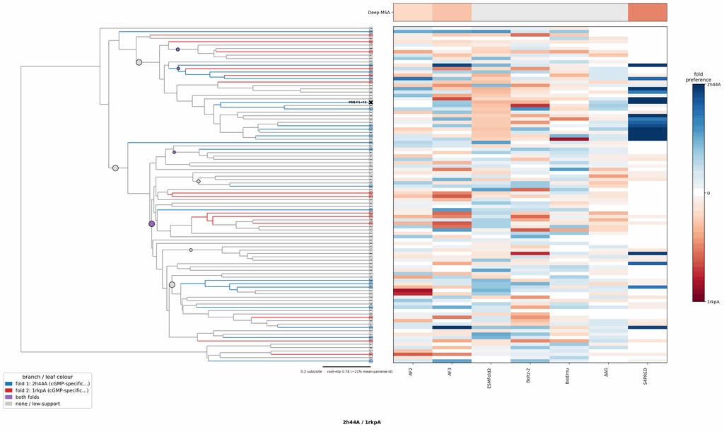

## Figure 2: Aligned overlay (both folds superposed)

The single fold-switching chain of each fold superposed by TM-align; waters hidden, any ligand shown as green sticks. Grey = structurally conserved core, colour = divergent (fold-switching) region.

2h44A (cGMP-specific 3',5'-cyclic phosphodiesterase)1rkpA (cGMP-specific 3',5'-cyclic phosphodiesterase)Ligand 7CA (bound to 2h44A), Ligand IBM (bound to 1rkpA)

TM-score: 0.927 · Trigger class: ligand

Aligned overlay

## Figure 3: The two folds, side by side

Each fold is coloured by per-residue Cα deviation between the two superposed structures: grey ≈ conserved core, full colour = structurally divergent (fold-switching) region.

2h44A (cGMP-specific 3',5'-cyclic phosphodiesterase)

1rkpA (cGMP-specific 3',5'-cyclic phosphodiesterase)

0 Å5≥10 Å

2h44A (cGMP-specific 3',5'-cyclic phosphodiesterase)

1rkpA (cGMP-specific 3',5'-cyclic phosphodiesterase)

## Figure 4: Best-cluster predicted contact maps over the two true folds.

Predicted contact maps (MSA-Transformer) for the clusters best matching each fold, over the true contacts of fold 1 (upper triangle) and fold 2 (lower). Divergent contacts between clusters are the contact-level signature of fold-switching.

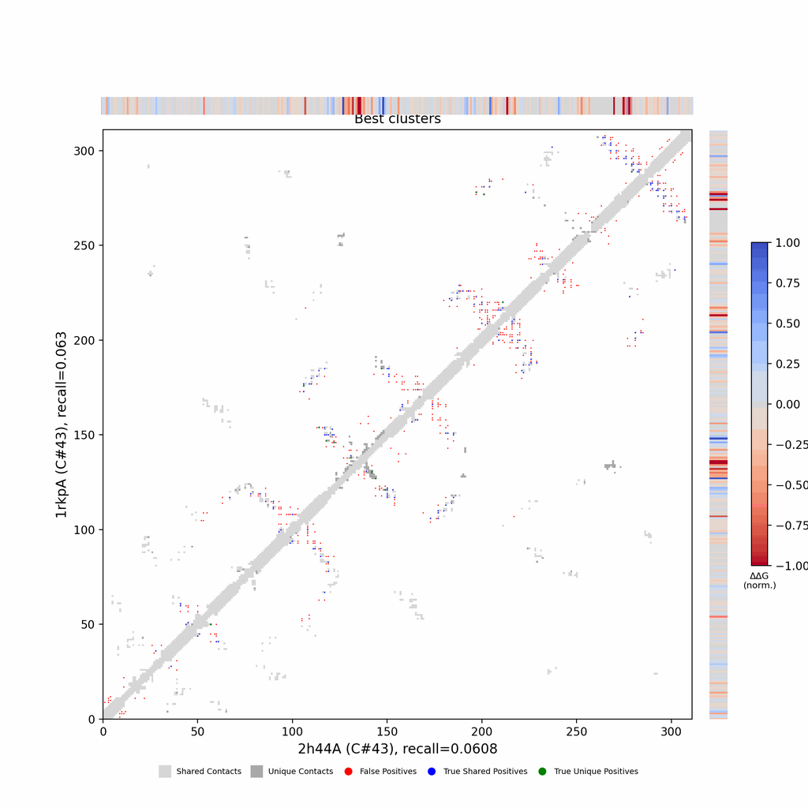

## Figure 5: Per-residue ΔΔG fold-preference contribution

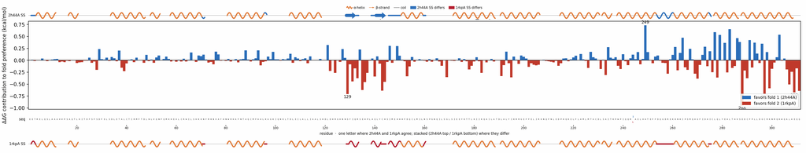

**More figures**

## Figure 6: Deep-MSA contact map panel / Best clusters contact map panel

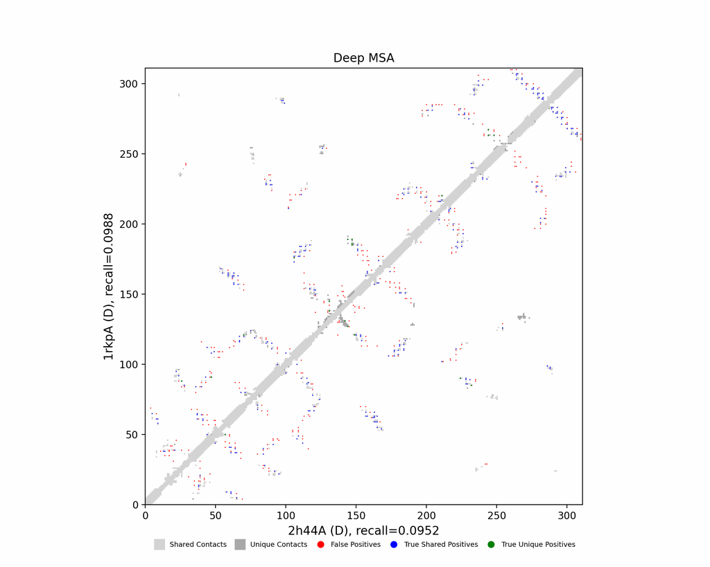

Deep-MSA contact map panel

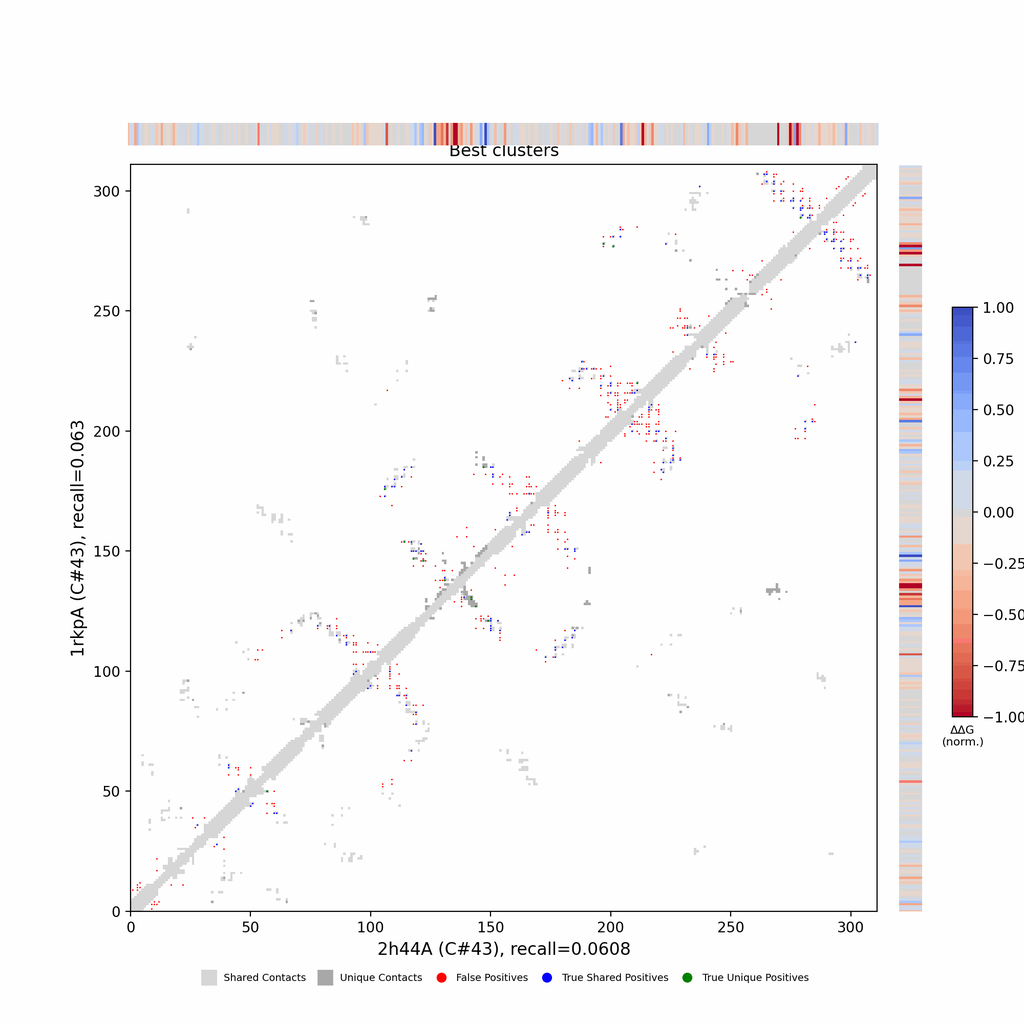

Best clusters contact map panel

## Figure 7: All clusters contact-map mosaic (small multiples).

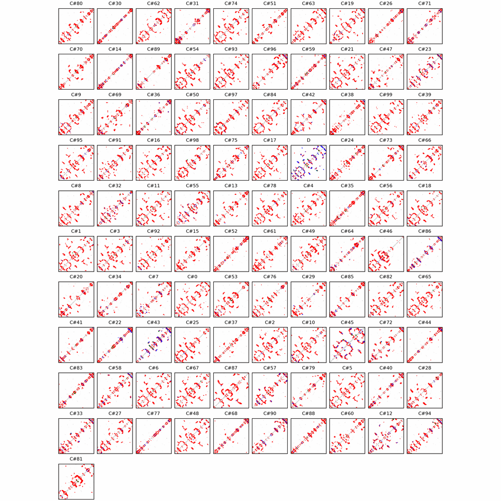

## Figure 8: Phylo null: tree with shuffled cluster fold labels.

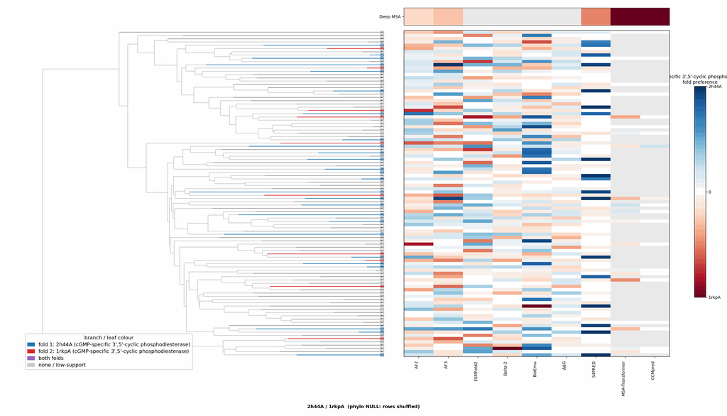

## Cluster metrics table

Per-cluster metrics underlying the figures above.

| cluster | n | neff | AF2_TM1 | AF2_TM2 | AF3_TM1 | AF3_TM2 | RE-MSAT-COM | RE-MSAT1 | RE-MSAT2 | ESM_SEQIDS | ESM_TM1 | ESM_TM2 | ΔΔG_Bias | ΔΔG_Bias_std | ΔΔG_frac_F1 | Boltz2_pref | S4PRED_pref | CCMpred_pref | BioEmu_pref |
| --- | --- | --- | --- | --- | --- | --- | --- | --- | --- | --- | --- | --- | --- | --- | --- | --- | --- | --- | --- |
| Deep | - | - | 0.94 | 0.96 | 0.94 | 0.96 | 0.44 | 0.43 | 0.45 | - | - | - | - | - | - | - | -0.02 | -0.01 | - |
| 000 | 768.0 | 304.0 | 0.66 | 0.68 | 0.79 | 0.75 | 0.0 | 0.0 | 0.0 | 002; 002; 003; 003; 008; 008; 001; 009; 001; 009 | 0.83 ± 0.02 | 0.86 ± 0.02 | -7.86 | 5.08 | 0.1 | -0.01 | 0.02 | -0.0 | -0.01 |
| 001 | 645.0 | 401.0 | 0.78 | 0.78 | 0.81 | 0.83 | 0.01 | 0.01 | 0.01 | 001; 001; 003; 004; 003; 004; 002; 008; 002; 008 | 0.87 ± 0.04 | 0.90 ± 0.03 | -8.3 | 4.74 | 0.1 | -0.0 | -0.02 | 0.0 | -0.02 |
| 002 | 645.0 | 442.0 | 0.92 | 0.94 | 0.94 | 0.96 | 0.01 | 0.01 | 0.01 | 001; 001; 003; 003; 009; 009; 002; 010; 002; 010 | 0.82 ± 0.01 | 0.85 ± 0.02 | -7.62 | 4.82 | 0.0 | -0.06 | -0.02 | 0.0 | 0.01 |
| 003 | 445.0 | 264.0 | 0.25 | 0.26 | 0.21 | 0.22 | 0.01 | 0.01 | 0.01 | 003; 003; 005; 005; 001; 004; 001; 004; 002; 002 | 0.86 ± 0.02 | 0.88 ± 0.02 | -5.63 | 3.27 | 0.0 | -0.01 | -0.02 | 0.0 | -0.01 |
| 004 | 409.0 | 135.0 | 0.41 | 0.43 | 0.85 | 0.85 | 0.0 | 0.0 | 0.0 | 001; 001; 002; 002; 005; 003; 003; 005; 004; 004 | 0.82 ± 0.10 | 0.83 ± 0.10 | -5.54 | 4.53 | 0.1 | 0.0 | -0.02 | 0.0 | -0.02 |
| 005 | 382.0 | 260.0 | 0.93 | 0.95 | 0.94 | 0.95 | 0.01 | 0.01 | 0.01 | 002; 002; 006; 006; 007; 007; 009; 009; 001; 001 | 0.81 ± 0.04 | 0.83 ± 0.04 | -9.56 | 6.22 | 0.1 | -0.02 | -0.02 | 0.0 | 0.01 |
| 006 | 329.0 | 230.0 | 0.25 | 0.23 | 0.26 | 0.27 | 0.01 | 0.01 | 0.01 | 004; 004; 002; 002; 001; 001; 009; 010; 010; 009 | 0.82 ± 0.03 | 0.85 ± 0.02 | -8.49 | 3.86 | 0.0 | -0.02 | -0.02 | 0.0 | 0.0 |
| 007 | 320.0 | 86.0 | 0.3 | 0.29 | 0.65 | 0.67 | 0.03 | 0.03 | 0.03 | 002; 002; 003; 003; 001; 006; 001; 006; 009; 009 | 0.84 ± 0.01 | 0.86 ± 0.01 | -7.7 | 4.08 | 0.0 | -0.02 | -0.02 | 0.0 | -0.01 |
| 008 | 305.0 | 66.0 | 0.26 | 0.26 | 0.31 | 0.31 | 0.0 | 0.0 | 0.0 | 001; 001; 002; 002; 005; 005; 003; 003; 008; 008 | 0.84 ± 0.03 | 0.87 ± 0.02 | -6.35 | 3.35 | 0.0 | -0.03 | -0.02 | 0.0 | -0.0 |
| 009 | 293.0 | 72.0 | 0.52 | 0.56 | 0.61 | 0.63 | 0.0 | 0.0 | 0.0 | 002; 002; 004; 004; 010; 010; 001; 001; 003; 003 | 0.84 ± 0.03 | 0.87 ± 0.04 | -5.32 | 5.23 | 0.2 | -0.04 | -0.02 | 0.0 | -0.01 |
| 010 | 277.0 | 156.0 | 0.26 | 0.24 | 0.24 | 0.26 | 0.03 | 0.03 | 0.03 | 001; 001; 005; 005; 009; 009; 008; 008; 003; 003 | 0.77 ± 0.07 | 0.80 ± 0.09 | -8.48 | 5.04 | 0.0 | -0.04 | -0.02 | 0.0 | -0.0 |
| 011 | 269.0 | 201.0 | 0.9 | 0.92 | 0.92 | 0.93 | 0.02 | 0.01 | 0.02 | 002; 002; 001; 008; 008; 004; 001; 004; 009; 009 | 0.79 ± 0.05 | 0.83 ± 0.04 | -8.28 | 4.79 | 0.0 | 0.0 | -0.02 | 0.0 | 0.01 |
| 012 | 248.0 | 73.0 | 0.22 | 0.3 | 0.44 | 0.46 | 0.06 | 0.05 | 0.06 | 003; 003; 001; 002; 002; 001; 009; 009; 010; 010 | 0.82 ± 0.04 | 0.85 ± 0.03 | -6.43 | 3.01 | 0.0 | -0.01 | -0.02 | 0.0 | -0.0 |
| 013 | 243.0 | 52.0 | 0.36 | 0.38 | 0.54 | 0.56 | 0.0 | 0.0 | 0.0 | 006; 006; 005; 005; 002; 002; 001; 003; 001; 003 | 0.82 ± 0.03 | 0.84 ± 0.03 | -6.1 | 5.03 | 0.2 | -0.0 | -0.02 | 0.0 | -0.01 |
| 014 | 240.0 | 7.0 | 0.34 | 0.38 | 0.4 | 0.45 | 0.01 | 0.01 | 0.0 | 001; 001; 008; 008; 002; 002; 003; 003; 004; 004 | 0.87 ± 0.03 | 0.89 ± 0.03 | -6.68 | 2.9 | 0.0 | -0.05 | -0.02 | 0.0 | -0.02 |
| 015 | 230.0 | 47.0 | 0.43 | 0.44 | 0.34 | 0.32 | 0.0 | 0.0 | 0.0 | 006; 006; 001; 007; 007; 003; 001; 003; 009; 009 | 0.84 ± 0.01 | 0.87 ± 0.01 | -10.25 | 5.48 | 0.1 | -0.06 | -0.02 | 0.0 | -0.03 |
| 016 | 218.0 | 121.0 | 0.42 | 0.39 | 0.44 | 0.42 | 0.01 | 0.01 | 0.01 | 002; 002; 001; 003; 001; 003; 007; 007; 005; 005 | 0.83 ± 0.02 | 0.85 ± 0.02 | -7.31 | 4.32 | 0.1 | -0.01 | -0.02 | 0.0 | 0.01 |
| 017 | 216.0 | 88.0 | 0.46 | 0.49 | 0.38 | 0.4 | 0.0 | 0.0 | 0.0 | 004; 004; 002; 006; 006; 002; 001; 001; 005; 005 | 0.85 ± 0.02 | 0.86 ± 0.02 | -9.34 | 6.63 | 0.0 | -0.01 | -0.02 | 0.0 | -0.01 |
| 018 | 211.0 | 113.0 | 0.26 | 0.27 | 0.57 | 0.56 | 0.01 | 0.01 | 0.01 | 003; 003; 001; 001; 004; 004; 009; 009; 002; 002 | 0.81 ± 0.06 | 0.84 ± 0.06 | -5.49 | 4.64 | 0.2 | -0.05 | -0.02 | 0.0 | -0.01 |
| 019 | 207.0 | 58.0 | 0.42 | 0.42 | 0.76 | 0.8 | 0.02 | 0.02 | 0.02 | 003; 003; 001; 001; 009; 009; 004; 004; 010; 010 | 0.81 ± 0.05 | 0.83 ± 0.05 | -5.42 | 4.3 | 0.1 | -0.05 | -0.02 | 0.0 | -0.01 |
| 020 | 204.0 | 50.0 | 0.25 | 0.24 | 0.3 | 0.29 | 0.01 | 0.0 | 0.0 | - | - | - | -6.01 | 6.26 | 0.2 | -0.04 | -0.02 | - | 0.01 |
| 021 | 202.0 | 149.0 | 0.92 | 0.93 | 0.94 | 0.96 | 0.01 | 0.01 | 0.01 | - | - | - | -8.05 | 4.34 | 0.0 | -0.01 | -0.02 | - | -0.01 |
| 022 | 185.0 | 23.0 | 0.32 | 0.34 | 0.29 | 0.29 | 0.05 | 0.05 | 0.04 | - | - | - | -4.26 | 4.97 | 0.1 | -0.04 | 0.02 | - | -0.01 |
| 023 | 180.0 | 54.0 | 0.28 | 0.31 | 0.3 | 0.31 | 0.06 | 0.06 | 0.06 | - | - | - | -10.17 | 4.42 | 0.0 | 0.02 | -0.02 | - | -0.0 |
| 024 | 180.0 | 40.0 | 0.29 | 0.29 | 0.32 | 0.27 | 0.01 | 0.0 | 0.0 | - | - | - | -6.32 | 3.16 | 0.1 | 0.01 | 0.01 | - | -0.02 |
| 025 | 177.0 | 145.0 | 0.9 | 0.92 | 0.96 | 0.94 | 0.01 | 0.01 | 0.01 | - | - | - | -7.22 | 5.66 | 0.2 | -0.0 | -0.02 | - | 0.0 |
| 026 | 175.0 | 20.0 | 0.32 | 0.33 | 0.31 | 0.34 | 0.0 | 0.0 | 0.0 | - | - | - | -8.18 | 5.45 | 0.0 | -0.04 | 0.02 | - | -0.02 |
| 027 | 173.0 | 66.0 | 0.27 | 0.27 | 0.7 | 0.73 | 0.01 | 0.01 | 0.01 | - | - | - | -11.48 | 5.03 | 0.0 | -0.0 | -0.02 | - | -0.0 |
| 028 | 173.0 | 33.0 | 0.28 | 0.27 | 0.34 | 0.35 | 0.01 | 0.01 | 0.01 | - | - | - | -12.14 | 5.46 | 0.0 | -0.04 | -0.02 | - | -0.01 |

[output cut: 71 more lines]